# R workflow

# Agenda

- R & RStudio Workflow
- Quarto
- Coding Basics
- Getting Started

# Learning objectives

By the end of the lecture, you will be able to …

- setup a workflow using R and RStudio
- use R to conduct basic calculations/comparisons
- familiarize yourself with a dataset using R and RStudio
- create a reproducible report using Quarto

# R & RStudio Tour

## Tour: RStudio Panes

Sit back and enjoy the show!

## Mini-task

Open a new R Script.

Click the dropdown arrow next to the “New File icon,” and then “R script”.

[video not shown]

Alternatively, hold down “Ctrl” + “Shift” + “N.”

## Mini-tasks

Type `2 + 2` in the Console. Then push `Enter`.

Type `2 + 2` in the R Script Then click `Run`.

## Documentation

[figure not shown]

[figure not shown]

## Mini-task

Add a comment above your `2 + 2` code in your R script. Then click `Run`.

## Tour recap: Panes

There are four key regions or “panes” in the interface:

1. [**Source pane:**](https://docs.posit.co/ide/user/ide/guide/ui/ui-panes.html#source) where you can edit and save R scripts or author computational documents like Quarto and R Markdown.
2. [**Console pane:**](https://docs.posit.co/ide/user/ide/guide/ui/ui-panes.html#console) is used to write short interactive R commands.
3. [**Environment pane:**](https://docs.posit.co/ide/user/ide/guide/ui/ui-panes.html#environment-pane) displays temporary R objects created during that R session.
4. [**Output pane:**](https://docs.posit.co/ide/user/ide/guide/ui/ui-panes.html#output-pane) displays the plots, tables, or HTML outputs of executed code along with files saved to disk.

**Heads Up!**

The top-left panel (source pane) and can be launched by opening any editable file in RStudio.

[figure not shown]

## RStudio projects

Create a **RStudio project** for each data analysis project.

It supports an organized and reproducible workflow, cleanly separated from all other projects that you are working on. Everything you need in one place:

- local data files to load into RStudio.
- scripts to edit or run in bits or as a whole.
- Save your outputs (plots and cleaned data).

## File types

There are many file types, but these are key to an R & RStudio workflow (and likely new to you):

| Extension | Description |
| --- | --- |
| .Rproj | RStudio project file (keeps project settings). |
| .R | R scripts store a sequence of R commands (code) that can be run all at once or line by line. |
| .qmd | Quarto Markdown creates reproducible documents that contain a combination of text, code, and output. |
| .Rdata (or sometimes .rda) | These store and load R objects—like data frames. |

## Mini-task

Create a new project in RStudio.

- Click: File > New Project.
- In the New Project wizard that pops up, select: New Directory, then New Project.
- Name the project “SOC6302”
- Click Browse and save the project anywhere **except** your downloads folder.
- Click: Create Project.
- This will launch you into a new RStudio Project inside a new folder called “SOC6302”.

## Mini-task

Clear the memory at every restart of RStudio.

Turn off the automatic saving of your workspace and .Rdata files when you quit RStudio. This is important for reproducibility, debugging, and avoiding littering your computer with unnecessary files.

**Set this via:**

1. Tools > Global Options.
2. Uncheck “Restore .RData into Workspace at Startup”.
3. Choose “Never” on the “Save workspace to .RData on exit”.
4. Click “Apply” and “OK”.

[figure not shown]

# Quarto

## Quarto

The tool you’ll use to create reproducible computational documents. Every piece of assignment you hand in will be a Quarto document.

- Fully reproducible reports
- R code + narrative

### RScript

- great for learning, exploring and tinkering.
- rerun it without attention to formatting or markdown.

### Quarto

- great for communicating analysis and results
- combines narrative explanation with code output (results).

## Tour: Quarto

Sit back and enjoy the show!

## Tour recap: Quarto

[figure not shown]

Source: [Dr. Mine Çetinkaya-Rundel](https://sta199-f24.github.io/slides/01-meet-the-toolkit-slides.html#/tour-recap-quarto)

## Tour recap: Quarto Code-chunks

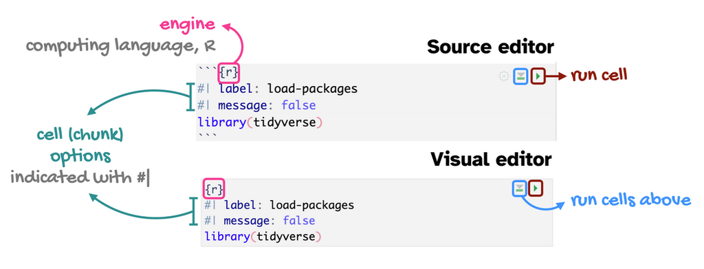

- **chunk labels** are helpful for describing what the code is doing, for jumping between code cells in the editor, and for troubleshooting
- `message: false` hides any messages emitted by the code in your rendered document

Source: [Dr. Mine Çetinkaya-Rundel](https://sta199-f24.github.io/slides/03-grammar-of-data-transformation-slides.html#/recap-code-cells-aka-code-chunks)

## How will we use Quarto?

- Every **code-along** and **milestone** will be a Quarto document
- The scaffolding will decrease over the course
- You will create and submit a Quarto document for your **research project**

[Tutorial: Hello, Quarto](https://quarto.org/docs/get-started/hello/rstudio.html)

# Your first code-along

[Download code-along-01.qmd](https://www.dropbox.com/scl/fi/dwa4lo3twg3tclza8jcm7/code-along-01.qmd?rlkey=u71pkl2vaw2fsgv1d0n4rgwza&dl=1)

## Mini-task

Save this code-along in your newly created project folder.

There’s no command in the R console to save scripts or Quarto files— you use the editor’s File > Save As or Ctrl+S.

# Coding Basics

## Coding basics

You can use R to do basic math calculations

```r
1 + 2
```

```
[1] 3
```

```r
2 * 5
```

```
[1] 10
```

```r
(1 + 2) / 2
```

```
[1] 1.5
```

You can create new objects with the assignment operator `<-`

```r
x <- 3 * 4
x
```

```
[1] 12
```

You can (and should) make comments in your code

```r
# R will ignore any text after # for that line

primes <- c(2, 3, 5, 7, 11, 13) # create vector of prime numbers
primes
```

```
[1]  2  3  5  7 11 13
```

Object names must start with a letter and can only contain letters, numbers, _, and .

```
i_use_snake_case
otherPeopleUseCamelCase
some.people.use.periods
And_aFew.People_RENOUNCEconvention
```

Source: [R for Data Science](https://r4ds.hadley.nz/workflow-basics.html)

## Coding basics: demo

```r
a <- 7
b <- 3
addition <- a + b
subtraction <- a - b
multiplication <- a * b
division <- a / b
exponentiation <- a^2
```

```r
a
```

```
[1] 7
```

```r
b
```

```
[1] 3
```

```r
addition
```

```
[1] 10
```

```r
subtraction
```

```
[1] 4
```

```r
multiplication
```

```
[1] 21
```

```r
division
```

```
[1] 2.333333
```

```r
exponentiation
```

```
[1] 49
```

## Operators in R

[Operators in R](https://www.geeksforgeeks.org/r-language/r-operators/) are symbols directing R to perform various kinds of mathematical, logical, and decision operations. A few of the key ones to know before we get started:

**Assignment operators** assign values to variables:  
**<-, ->, =**

**Comparison operators** test equality or inequality:  
**==, !=, >, >=, <, <=**

**Logical operators** indicate “and”, “or”, and “not”:  
**&, |, !**

## Comparison operators

| operator | definition |
| --- | --- |
| `<` | is less than? |
| `<=` | is less than or equal to? |
| `>` | is greater than? |
| `>=` | is greater than or equal to? |
| `==` | is exactly equal to? |
| `!=` | is not equal to? |

## Comparison operators (cont)

```r
x <- 5
y <- 3
equal <- x == y
not_equal <- x != y
less_than <- x < y
more_than <- x > y
less_than_or_equal_to <- x <= y
more_than_or_equal_to <- x >= y
```

```r
x
```

```
[1] 5
```

```r
y
```

```
[1] 3
```

```r
equal
```

```
[1] FALSE
```

```r
not_equal
```

```
[1] TRUE
```

```r
less_than
```

```
[1] FALSE
```

```r
more_than
```

```
[1] TRUE
```

```r
less_than_or_equal_to
```

```
[1] FALSE
```

```r
more_than_or_equal_to
```

```
[1] TRUE
```

Source: [IONOS editorial team](https://www.ionos.ca/digitalguide/websites/web-development/r-operators/)

## Logical operators

| operator | definition |
| --- | --- |
| `x & y` | is x AND y? |
| `x \| y` | is x OR y? |
| `is.na(x)` | is x NA? |
| `!is.na(x)` | is x not NA? |

## Logical operators (cont)

```r
x <- TRUE
y <- FALSE

and_operator <- x & y
or_operator <- x | y
not_operator <- !x
```

```r
and_operator
```

```
[1] FALSE
```

```r
or_operator
```

```
[1] TRUE
```

```r
not_operator
```

```
[1] FALSE
```

Source: [IONOS editorial team](https://www.ionos.ca/digitalguide/websites/web-development/r-operators/)

## Mini-task

Make a tiny data frame and save it.

```r
df <- data.frame(x = c(1, 2, 3, 4, 5), y = c("a", "a", "b", "c", "c"))

df # look at df
```

```
  x y
1 1 a
2 2 a
3 3 b
4 4 c
5 5 c
```

# Getting Started

## Comprehensive R Archive Network (CRAN)

CRAN is like an App Store for R. It hosts R packages, documentation, and source code contributed by users worldwide. It is mediated (e.g., quality controlled), making it incredibly reliable.

## Packages

R comes with basic tools, but **packages** extend the capabilities of base R (what you already installed). An R package is like a toolbox: a collection of functions, data, and documentation that help you do specific tasks using R.

**You’ll install each package (1X per system):**

```r
install.packages("tidyverse")
```

**You’ll load each package (every time you use it):**

```r
library(tidyverse)
```

## Mini-task

Install the `tidyverse()` package, available on CRAN.

**Run the code chunk in your code-along.**

*OR:* Copy and paste the code into your Console pane. Then hit “Enter”.

```r
install.packages("tidyverse")
```

## Mini-tasks

Install the `tinytex()` package, available on CRAN.

**Run the code chunk in your code-along.**

*OR:* Copy and paste the code into your Console pane. Then hit “Enter”.

```r
install.packages('tinytex')
```

```r
tinytex::install_tinytex()
```

## Mini-tasks

Install the `gssr()` package, NOT on CRAN.

```r
# Install 'gssr' from 'ropensci' universe
install.packages('gssr', repos =
  c('https://kjhealy.r-universe.dev', 'https://cloud.r-project.org'))
```

Install the `gssrdoc()` package, NOT on CRAN.

```r
# Install 'gssrdoc' from 'ropensci' universe
install.packages('gssrdoc', repos =
  c('https://kjhealy.r-universe.dev', 'https://cloud.r-project.org'))
```

## Mini-task

Load the packages.

**Run the code chunk in your code-along.**

```r
library(tidyverse) # for data wrangling
library(gssr) # U.S. General Social Survey data
library(gssrdoc) # GSS documentation
```

## Environment

**Run the code chunk in your code-along.**

## Meet your data

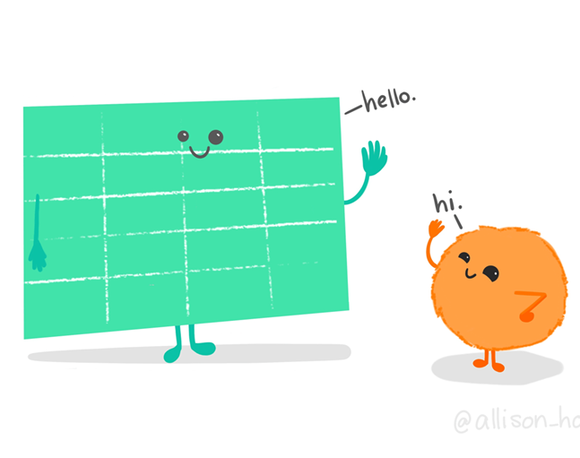

We’re going to use data from the [U.S. General Social Survey (GSS)](https://gss.norc.org/us/en/gss/about-the-gss.html).

## Load some data

**Run the code chunk in your code-along.**

```r
# Load the data (will appear in your Global Environment pane)
gss24 <- gss_get_yr(2024)

# Preview the data named gss24
gss24
```

```
# A tibble: 3,986 × 989
   year       id wrkstat hrs1        hrs2        evwork      wrkslf  occ10
   <dbl+l> <dbl> <dbl+l> <dbl+lbl>   <dbl+lbl>   <dbl+lbl>   <dbl+l> <dbl+lbl>
 1 2024        1 1 [wor…    43       NA(i) [iap] NA(i) [iap] 2 [som…   230 [edu…
 2 2024        2 5 [ret… NA(i) [iap] NA(i) [iap]     1 [yes] 2 [som…   800 [acc…
 3 2024        3 5 [ret… NA(i) [iap] NA(i) [iap]     1 [yes] 2 [som…   430 [man…
 4 2024        4 2 [wor…    20       NA(i) [iap] NA(i) [iap] 2 [som…  4760 [ret…
 5 2024        5 5 [ret… NA(i) [iap] NA(i) [iap]     1 [yes] 2 [som…  5860 [off…
 6 2024        6 4 [une… NA(i) [iap] NA(i) [iap] NA(i) [iap] 1 [sel…  4000 [che…
 7 2024        7 1 [wor…    80       NA(i) [iap] NA(i) [iap] 2 [som…  9640 [pac…
 8 2024        8 6 [in … NA(i) [iap] NA(i) [iap]     1 [yes] 2 [som…  3600 [nur…
 9 2024        9 1 [wor…    50       NA(i) [iap] NA(i) [iap] 2 [som… NA(n) [no …
10 2024       10 4 [une… NA(i) [iap] NA(i) [iap] NA(i) [iap] 2 [som…  5620 [sto…
# ℹ 3,976 more rows
# ℹ 981 more variables: prestg10 <dbl+lbl>, prestg105plus <dbl+lbl>,
#   indus10 <dbl+lbl>, marital <dbl+lbl>, martype <dbl+lbl>, divorce <dbl+lbl>,
#   widowed <dbl+lbl>, spwrksta <dbl+lbl>, sphrs1 <dbl+lbl>, sphrs2 <dbl+lbl>,
#   spevwork <dbl+lbl>, cowrksta <dbl+lbl>, cowrkslf <dbl+lbl>,
#   coevwork <dbl+lbl>, cohrs1 <dbl+lbl>, cohrs2 <dbl+lbl>, spwrkslf <dbl+lbl>,
#   spocc10 <dbl+lbl>, sppres10 <dbl+lbl>, sppres105plus <dbl+lbl>, …
```

## Browse dataframe

Open the `gss24` dataframe.

With your mouse, go to the environment panel (upper-right) and click on the `gss24` object. It opens in a tab on the source pane.

This is often a good idea to browse data to get a first feel for the data, but only if your dataset is relatively small.

[figure not shown]

## Variable documentation

The [GSS documentation](https://gss.norc.org/us/en/gss/get-documentation.html) is available online in .pdf form.

Because we loaded the `gssrdoc` package, for information about a specific GSS variable:  
type `?varname` at the console.

In the output pane, the `Help` tab will show the variable documentation.

**Heads Up!**

Replace “varname” with the name of a variable.  
Example: `?meovrwrk`

## Variable documentation example

```
meovrwrk {gssrdoc}  R Documentation
Men hurt family when focus on work too much
Description
meovrwrk

Details
Question 1297. And, do you agree or disagree: c. Family life often suffers because men concentrate too much on their work.

Overview
For further details see the official GSS documentation.

Counts by year:

year    iap agree   can't choose    disagree    neither agree nor disagree  no answer   strongly agree  strongly disagree   skipped on web  Total
1972    1613    -   -   -   -   -   -   -   -   1613
1973    1504    -   -   -   -   -   -   -   -   1504
1974    1484    -   -   -   -   -   -   -   -   1484
1975    1490    -   -   -   -   -   -   -   -   1490
1976    1499    -   -   -   -   -   -   -   -   1499
1977    1530    -   -   -   -   -   -   -   -   1530
1978    1532    -   -   -   -   -   -   -   -   1532
1980    1468    -   -   -   -   -   -   -   -   1468
1982    1860    -   -   -   -   -   -   -   -   1860
1983    1599    -   -   -   -   -   -   -   -   1599
1984    1473    -   -   -   -   -   -   -   -   1473
1985    1534    -   -   -   -   -   -   -   -   1534
1986    1470    -   -   -   -   -   -   -   -   1470
1987    1819    -   -   -   -   -   -   -   -   1819
1988    1481    -   -   -   -   -   -   -   -   1481
1989    1537    -   -   -   -   -   -   -   -   1537
1990    1372    -   -   -   -   -   -   -   -   1372
1991    1517    -   -   -   -   -   -   -   -   1517
1993    1606    -   -   -   -   -   -   -   -   1606
1994    1545    695 33  243 286 27  122 41  -   2992
1996    1444    825 16  198 169 1   230 21  -   2904
1998    2832    -   -   -   -   -   -   -   -   2832
2000    940 877 43  361 331 22  209 34  -   2817
2002    1857    415 6   264 108 -   99  16  -   2765
2004    1906    460 4   188 135 -   94  25  -   2812
2006    2518    945 14  477 304 1   208 43  -   4510
```

[output cut: 34 more lines]

```

NA(s) skipped on web

NA(u) uncodeable

NA(x) not available in this release

NA(y) not available in this year

NA(z) see codebook

Source
General Social Survey https://gss.norc.org

[Package gssrdoc version 0.7.0 Index]
```

## Variables

You can access the variables (i.e., columns) using the `$` operator, as shown using the `table()` function. The variable names are case sensitive.

```r
table(gss24$meovrwrk)
```

```
  1   2   3   4   5
238 938 797 534 108
```

## Mini-tasks

Change the code to show the variable `fefam`.

```r
# Replace meovrwrk with fefam
table(gss24$meovrwrk)
```

```
  1   2   3   4   5
238 938 797 534 108
```

add text to your code-along that interprets the results for the `2` value for `fefam`.

## Quarto: Render

Finally, let’s `render` your code-along-01 and see the results!

[figure not shown]

**Heads Up!**

Click the down arrow next to `render` to choose whether to preview within RStudio’s Viewer Pane or in your browser.

# Support

Some help videos and further explanation:

[R - Intro RStudio Interface](https://youtu.be/opy-v0WAHXM)

[EasyR - Getting started with R the easy way](https://youtu.be/K9-zDmq737I)